# Marketing_Campaign_for_Banking_Products_I S_Hrishikesh_Gadekar

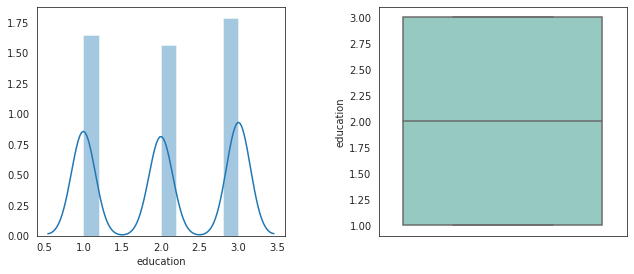

```python
# Upsampled Data
fig, axes = plt.subplots(1, 2, figsize=(10,5))

sns.distplot(X_upsampled_train["education"], ax=axes[0]);
sns.boxplot(X_upsampled_train["education"], orient="v", palette="Set3", ax=axes[1])

fig.tight_layout(pad=5.0)
```

*Observation*: There are no Outliers for the 'Education' feature.

```
Feature 7: 'Mortgage' is our Numerical Interval data.
```

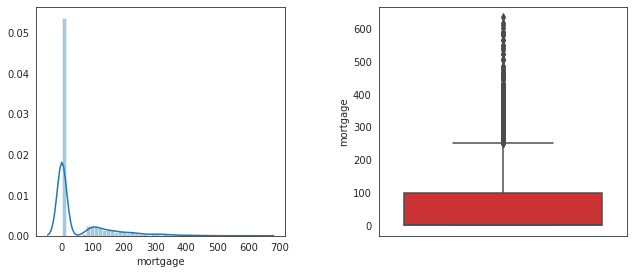

```python
# Main Data
fig, axes = plt.subplots(1, 2, figsize=(10,5))

sns.distplot(X_train["mortgage"], ax=axes[0]);
sns.boxplot(X_train["mortgage"], orient="v", palette="Set1", ax=axes[1])

fig.tight_layout(pad=5.0)
```

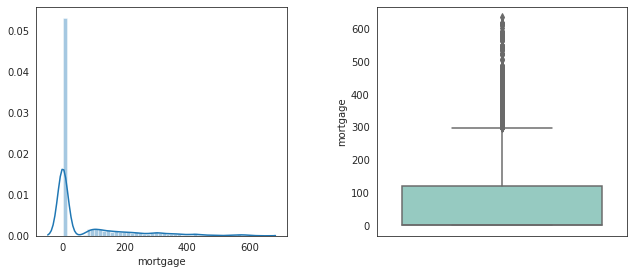

```python
# Upsampled Data
fig, axes = plt.subplots(1, 2, figsize=(10,5))

sns.distplot(X_upsampled_train["mortgage"], ax=axes[0]);
sns.boxplot(X_upsampled_train["mortgage"], orient="v", palette="Set3", ax=axes[1])

fig.tight_layout(pad=5.0)
```

*Observation*: The Distribution of 'Mortgage' feature is highly skewed and there are a lot of Outliers as well. We can construct an ordinal categorical feature 'int_mortgage' using the 'Mortgage' feature and then drop Mortgage feature. Same procedure will be applied to test_X as well, again, in both the Datasets.

```python
# Main Data
X_train["int_mortgage"] = pd.cut(X_train["mortgage"],
                                bins=[0,100,200,300,400,500,600,700],
                                labels=[0,1,2,3,4,5,6],
                                include_lowest=True)

X_train.drop("mortgage", axis=1, inplace=True)

X_test["int_mortgage"] = pd.cut(X_test["mortgage"],
                                bins=[0,100,200,300,400,500,600,700],
                                labels=[0,1,2,3,4,5,6],
                                include_lowest=True)

X_test.drop("mortgage", axis=1, inplace=True)
```

```python
# Upsampled Data
X_upsampled_train["int_mortgage"] = pd.cut(X_upsampled_train["mortgage"],
                                bins=[0,100,200,300,400,500,600,700],
                                labels=[0,1,2,3,4,5,6],
                                include_lowest=True)

X_upsampled_train.drop("mortgage", axis=1, inplace=True)

X_upsampled_test["int_mortgage"] = pd.cut(X_upsampled_test["mortgage"],
                                bins=[0,100,200,300,400,500,600,700],
                                labels=[0,1,2,3,4,5,6],
                                include_lowest=True)

X_upsampled_test.drop("mortgage", axis=1, inplace=True)
```

The remaining features are Binary Categorical. Thus, no Outlier Analysis is required.

Now let's perform **'Standardization'** on our Dataset to increase our learning performance. *StandardScaler* of scikit-learn will be used. A StandardScaler is fit to the feature in X_train, then this scaler transforms the same feature in X_train and X_test. This process is repeated for all features.

```python
# Main Data
for ind, column in enumerate(X_train.columns):
    scaler = StandardScaler()

    # fit to the training data
    scaler.fit(X_train[[column]])

    # transform the training data
    np_array = scaler.transform(X_train[[column]])
    X_train.loc[:, column] = pd.Series(np_array.flatten())

    # transform the test data
    np_array = scaler.transform(X_test[[column]])
    X_test.loc[:, column] = pd.Series(np_array.flatten())
```

```python
# Upsampled Data
for ind, column in enumerate(X_upsampled_train.columns):
    scalerus = StandardScaler()

    # fit to the training data
    scalerus.fit(X_upsampled_train[[column]])

    # transform the training data
    np_arrayus = scalerus.transform(X_upsampled_train[[column]])
    X_upsampled_train.loc[:, column] = pd.Series(np_arrayus.flatten())

    # transform the test data
    np_arrayus = scalerus.transform(X_upsampled_test[[column]])
    X_upsampled_test.loc[:, column] = pd.Series(np_arrayus.flatten())
```

Now, after Transformation, we will again inspect the linear correlations between features and also between features and output.

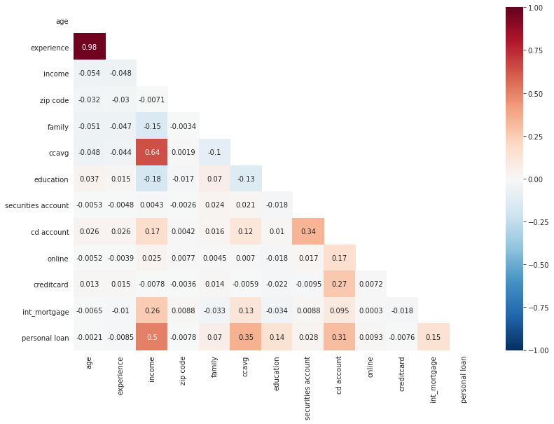

```python
# Main Data
corr_matrix = pd.concat([X_train, y_train], axis=1).corr()
mask = np.triu(np.ones_like(corr_matrix, dtype=np.bool))

plt.figure(figsize=(13,9))
sns.heatmap(corr_matrix,annot=True,vmin=-1,vmax=1,center=0, mask=mask,cmap="RdBu_r");
```

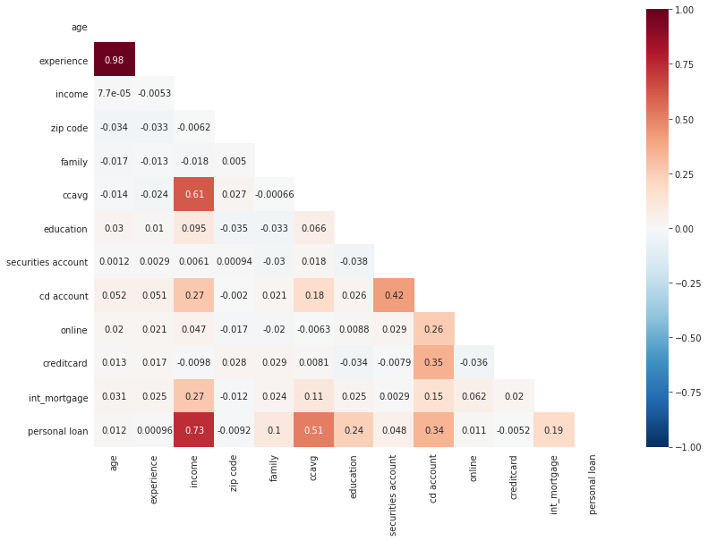

```python
# Upsampled Data
corr_matrixus = pd.concat([X_upsampled_train, Y_upsampled_train], axis=1).corr()
maskus = np.triu(np.ones_like(corr_matrixus, dtype=np.bool))

plt.figure(figsize=(13,9))
sns.heatmap(corr_matrixus,annot=True,vmin=-1,vmax=1,center=0, mask=maskus,cmap="RdBu_r");
```

```python
# Main Data
X_train.drop("experience", axis=1, inplace=True)
X_test.drop("experience", axis=1, inplace=True)
```

```python
# Upsampled Data
X_upsampled_train.drop("experience", axis=1, inplace=True)
X_upsampled_test.drop("experience", axis=1, inplace=True)
```

#### **6) Model Training & Prediction**

Now comes the stage of our actual Model bulding. As we know, there are two Datasets with us: i) **Main Dataset** which contains all the original given values, ii) **Upsampled Dataset** which is created with an intent to make our model unbiased.

Our idea is simple- We will apply 5 Classifier Models viz. 'Logistic Regression', 'KNN Classifier', 'Naive Bayes', 'Random Forest' and 'Decision Tree' on both the Datasets.

We then compare the results and conclude with the best fit model using the measures of Accuracy, F1 score, Recall ROC, AUC etc.

*First let's start with the Main Dataset. We will apply everything same on the Upsampled Dataset after this.*

##### M1) Logistic Regression Model

Let's apply Logistic Regression method and check the Performance Metrics.

```python
logmodel = LogisticRegression();
logmodel.fit(X_train, y_train);
```

*Prediction and Evaluation:*

```python
logmodel.score(X_train, y_train)
```

```
0.952
```

```python
logmodel.score(X_test, y_test)
```

```
0.9513333333333334
```

```python
logmodel_predicttr = logmodel.predict(X_train)
```

```python
logmodel_predictts = logmodel.predict(X_test)
```

```
The Report for Logistic Regression Model is:
```

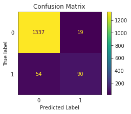

```
              precision    recall  f1-score   support

           0       0.96      0.99      0.97      1356
           1       0.83      0.62      0.71       144

    accuracy                           0.95      1500
   macro avg       0.89      0.81      0.84      1500
weighted avg       0.95      0.95      0.95      1500

Accuracy Score on Training data for Logistic Regression is: 95.19999999999999
Accuracy Score on Test data for Logistic Regression is: 95.13333333333334
F1 Score  for Logistic Regression is: 84.24440028719798
```

```python
print('The Report for Logistic Regression Model is: \n')
matrix = plot_confusion_matrix(logmodel, X_test, y_test, values_format='d')
matrix.ax_.set_title('Confusion Matrix')
plt.xlabel('Predicted Label')
plt.gcf().axes[0].tick_params(color='black')
plt.gcf().axes[0].tick_params(color='black')
plt.gcf().set_size_inches(4,3)
plt.show()

print(classification_report(y_test,logmodel_predictts))

print("Accuracy Score on Training data for Logistic Regression is: {}".format(accuracy_score(y_train, logmodel_predicttr) * 100))
print("Accuracy Score on Test data for Logistic Regression is: {}".format(accuracy_score(y_test, logmodel_predictts) * 100))
print("F1 Score  for Logistic Regression is: {}".format(f1_score(y_test, logmodel_predictts, average="macro") * 100))
```

*Observations from LR Model*:

1. **Accuracy**: A very good accuracy score of 95.13% on the Test data.
2. **Recall**: A recall value of 62%, which means among the total number of customers who bought the loan, our model has predicted only 62% who bought the loan. This is not that great and won't benefit the bank much.
3. **Precision**: A Precision value of 83%, which means out of customers who we predicted to buy the loan, only 83% of them actually bought the loan. This is a decent score but could be improved.

##### M2) K-Nearest Neighbours (KNN) Model

Let's now apply KNN Algorithm and check if the accuracy improves.

```python
knn_model = KNeighborsClassifier(n_neighbors=21)
```

```python
knn_model.fit(X_train,y_train)
```

```
KNeighborsClassifier(algorithm='auto', leaf_size=30, metric='minkowski',
                     metric_params=None, n_jobs=None, n_neighbors=21, p=2,
                     weights='uniform')
```

*Prediction and Evaluation:*

```python
knn_model.score(X_train, y_train)
```

```
0.9465714285714286
```

```python
knn_model.score(X_test, y_test)
```

```
0.9493333333333334
```

```python
knn_predicttr = knn_model.predict(X_train)
```

```python
knn_predictts = knn_model.predict(X_test)
```

```
The Report for KNN Model is:
```

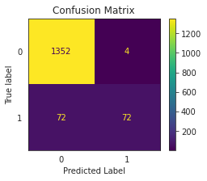

```
              precision    recall  f1-score   support

           0       0.95      1.00      0.97      1356
           1       0.95      0.50      0.65       144

    accuracy                           0.95      1500
   macro avg       0.95      0.75      0.81      1500
weighted avg       0.95      0.95      0.94      1500

Accuracy Score on Training data for KNN Classifier is: 94.65714285714286
Accuracy Score on Test data for KNN Classifier is: 94.93333333333334
F1 Score  for KNN Classifier is: 65.45454545454545
```

```python
print('The Report for KNN Model is: \n')
matrix = plot_confusion_matrix(knn_model, X_test, y_test, values_format='d')
matrix.ax_.set_title('Confusion Matrix')
plt.xlabel('Predicted Label')
plt.gcf().axes[0].tick_params(color='black')
plt.gcf().axes[0].tick_params(color='black')
plt.gcf().set_size_inches(4,3)
plt.show()

print(classification_report(y_test, knn_predictts))

print("Accuracy Score on Training data for KNN Classifier is: {}".format(accuracy_score(y_train, knn_predicttr) * 100))
print("Accuracy Score on Test data for KNN Classifier is: {}".format(accuracy_score(y_test, knn_predictts) * 100))
print("F1 Score  for KNN Classifier is: {}".format(f1_score(y_test, knn_predictts) * 100))
```

*Observations from KNN Model*:

1. **Accuracy**: A very good accuracy score of 94.93% on the Test data.
2. **Recall**: A recall value of 50%, which means among the total number of customers who bought the loan, our model has predicted only 50% who bought the loan. This is quite poor.
3. **Precision**: A Precision value of 95%, which means out of customers who we predicted to buy the loan, only 95% of them actually bought the loan. This is very good too.

##### M3) Naive Bayes Model

Let's now check the Decision tree Naive Bayes model.

```python
nb_model = GaussianNB()
```

```python
nb_model.fit(X_train, y_train);
```

*Prediction and Evaluation:*

```python
nb_model.score(X_train, y_train)
```

```
0.88
```

```python
nb_model.score(X_test, y_test)
```

```
0.8866666666666667
```

```python
nb_predicttr = nb_model.predict(X_train)
```

```python
nb_predictts = nb_model.predict(X_test)
```

```
The Report for Naive Bayes Model is:
```

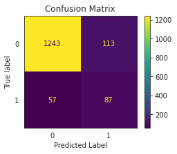

```
              precision    recall  f1-score   support

           0       0.96      0.92      0.94      1356
           1       0.43      0.60      0.51       144

    accuracy                           0.89      1500
   macro avg       0.70      0.76      0.72      1500
weighted avg       0.91      0.89      0.89      1500

Accuracy Score on Trianing data for Decision Tree Classifier is: 88.0
Accuracy Score on Test data for Decision Tree Classifier is: 88.66666666666667
F1 Score  for Decision Tree Classifier is: 50.58139534883721
```

```python
print('The Report for Naive Bayes Model is: \n')
matrix = plot_confusion_matrix(nb_model, X_test, y_test, values_format='d')
matrix.ax_.set_title('Confusion Matrix')
plt.xlabel('Predicted Label')
plt.gcf().axes[0].tick_params(color='black')
plt.gcf().axes[0].tick_params(color='black')
plt.gcf().set_size_inches(4,3)
plt.show()
print(classification_report(y_test, nb_predictts))

acc_score_nbtr = accuracy_score(y_train, nb_predicttr)
acc_score_nbts = accuracy_score(y_test, nb_predictts)
f1_score_nb = f1_score(y_test, nb_predictts)

print("Accuracy Score on Trianing data for Decision Tree Classifier is: {}".format(acc_score_nbtr * 100))
print("Accuracy Score on Test data for Decision Tree Classifier is: {}".format(acc_score_nbts * 100))
print("F1 Score  for Decision Tree Classifier is: {}".format(f1_score_nb * 100))
```

*Observations from NB Model*:

1. **Accuracy**: A good accuracy score of 88.67% on the Test data.
2. **Recall**: A recall value of 60%, which means among the total number of customers who bought the loan, our model has predicted only 60% who bought the loan. This is not that great and won't benefit the bank much.
3. **Precision**: A Precision value of 43%, which means out of customers who we predicted to buy the loan, only 43% of them actuallybought the loan. This is a quite bad score.

##### M4) Random Forest Classifier

Let's check the Random Forest Classifier performance.

```python
rfmodel = RandomForestClassifier(max_depth=2)
```

```python
rfmodel.fit(X_train, y_train)
```

```
RandomForestClassifier(bootstrap=True, ccp_alpha=0.0, class_weight=None,
                       criterion='gini', max_depth=2, max_features='auto',
                       max_leaf_nodes=None, max_samples=None,
                       min_impurity_decrease=0.0, min_impurity_split=None,
                       min_samples_leaf=1, min_samples_split=2,
                       min_weight_fraction_leaf=0.0, n_estimators=100,
                       n_jobs=None, oob_score=False, random_state=None,
                       verbose=0, warm_start=False)
```

*Prediction and Evaluation:*

```python
rfmodel.score(X_train, y_train)
```

```
0.9154285714285715
```

```python
rfmodel.score(X_test, y_test)
```

```
0.918
```

```python
rf_predicttr = rfmodel.predict(X_train)
```

```python
rf_predictts = rfmodel.predict(X_test)
```

```
The Report for Random Forest Classifier Model is:
```

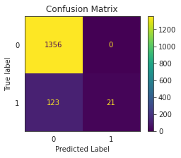

```
              precision    recall  f1-score   support

           0       0.92      1.00      0.96      1356
           1       1.00      0.15      0.25       144

    accuracy                           0.92      1500
   macro avg       0.96      0.57      0.61      1500
weighted avg       0.92      0.92      0.89      1500

Accuracy Score on Training data for Random Forest Classifier is: 91.54285714285714
Accuracy Score on Test data for Random Forest Classifier is: 91.8
F1 Score  for Random Forest Classifier is: 25.454545454545457
```

```python
print('The Report for Random Forest Classifier Model is: \n')
matrix = plot_confusion_matrix(rfmodel, X_test, y_test, values_format='d')
matrix.ax_.set_title('Confusion Matrix')
plt.xlabel('Predicted Label')
plt.gcf().axes[0].tick_params(color='black')
plt.gcf().axes[0].tick_params(color='black')
plt.gcf().set_size_inches(4,3)
plt.show()

print(classification_report(y_test, rf_predictts))

acc_score_rftr = accuracy_score(y_train, rf_predicttr)
acc_score_rfts = accuracy_score(y_test, rf_predictts)
f1_score_rf = f1_score(y_test, rf_predictts)

print("Accuracy Score on Training data for Random Forest Classifier is: {}".format(acc_score_rftr * 100))
print("Accuracy Score on Test data for Random Forest Classifier is: {}".format(acc_score_rfts * 100))
print("F1 Score  for Random Forest Classifier is: {}".format(f1_score_rf * 100))
```

*Observations from RF Model*:

1. **Accuracy**: A very good accuracy score of 91.80% on the Test data.
2. **Recall**: A recall value of 15%, which means among the total number of customers who bought the loan, our model has predicted only 15% who bought the loan. This is very poor and won't benefit the bank much.
3. **Precision**: A Precision value of 100%, which means out of customers who we predicted to buy the loan, all of them actually bought the loan. This is great.

##### M5) Decision Tree Classifier

Let's check the Decision Tree Classifier performance.

```python
dtmodel = DecisionTreeClassifier()
```

```python
dtmodel.fit(X_train, y_train)
```

```
DecisionTreeClassifier(ccp_alpha=0.0, class_weight=None, criterion='gini',
                       max_depth=None, max_features=None, max_leaf_nodes=None,
                       min_impurity_decrease=0.0, min_impurity_split=None,
                       min_samples_leaf=1, min_samples_split=2,
                       min_weight_fraction_leaf=0.0, presort='deprecated',
                       random_state=None, splitter='best')
```

Prediction and Evaluation:

```python
dtmodel.score(X_train, y_train)
```

```
1.0
```

```python
dtmodel.score(X_test, y_test)
```

```
0.982
```

```python
dt_predicttr = dtmodel.predict(X_train)
```

```python
dt_predictts = dtmodel.predict(X_test)
```

```
The Report for Decision Tree Classifier Model is:
```

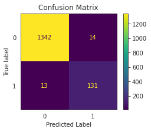

```
              precision    recall  f1-score   support

           0       0.99      0.99      0.99      1356
           1       0.90      0.91      0.91       144

    accuracy                           0.98      1500
   macro avg       0.95      0.95      0.95      1500
weighted avg       0.98      0.98      0.98      1500

Accuracy Score on Training data for  Decision Tree Classifier is: 100.0
Accuracy Score on Test data for  Decision Tree Classifier is: 98.2
F1 Score  for Decision Tree Classifier is: 90.65743944636678
```

```python
print('The Report for Decision Tree Classifier Model is: \n')
matrix = plot_confusion_matrix(dtmodel, X_test, y_test, values_format='d')
matrix.ax_.set_title('Confusion Matrix')
plt.xlabel('Predicted Label')
plt.gcf().axes[0].tick_params(color='black')
plt.gcf().axes[0].tick_params(color='black')
plt.gcf().set_size_inches(4,3)
plt.show()

print(classification_report(y_test, dt_predictts))


print("Accuracy Score on Training data for  Decision Tree Classifier is: {}".format(accuracy_score(y_train, dt_predicttr) * 100))
print("Accuracy Score on Test data for  Decision Tree Classifier is: {}".format(accuracy_score(y_test, dt_predictts) * 100))
print("F1 Score  for Decision Tree Classifier is: {}".format(f1_score(y_test, dt_predictts) * 100))
```

*Observations from DF Model*:

1. **Accuracy**: A very good accuracy score of 98.2% on the Test data. But it also shows 100% accuracy on the Training data which indicates a possibility of Overfitting.
2. **Recall**: A recall value of 91%, which means among the total number of customers who bought the loan, our model has predicted only 91% who bought the loan. This is great.
3. **Precision**: A Precision value of 90%, which means out of customers who we predicted to buy the loan, only 90% of them actuallybought the loan. This is great again.

#### **7) Comparing Model performance using ROC & AUC**

Let's use Receiver Operating Characteristic (ROC) curve and find the Area Under Curve (AUC) to evaluate the performance of our models with False postive ratio/True positive ratio.

```python
#Perform Predictions for all the models
PRED_PROB_LOG_RAW=logmodel.predict_proba(X_test)
PRED_PROB_KNN_RAW=knn_model.predict_proba(X_test)
PRED_PROB_NB_RAW=nb_model.predict_proba(X_test)
PRED_PROB_RF_RAW=rfmodel.predict_proba(X_test)
PRED_PROB_DT_RAW=dtmodel.predict_proba(X_test)
```

```python
#calculate fpr,tpr,threshold
fpr1, tpr1, thresh1 = roc_curve(y_test, PRED_PROB_LOG_RAW[:,1], pos_label=1)
fpr2,tpr2,thresh2 = roc_curve(y_test, PRED_PROB_KNN_RAW[:,1], pos_label=1)
fpr3,tpr3,thresh3 = roc_curve(y_test, PRED_PROB_NB_RAW[:,1], pos_label=1)
fpr4,tpr4,thresh4 = roc_curve(y_test, PRED_PROB_RF_RAW[:,1], pos_label=1)
fpr5,tpr5,thresh5 = roc_curve(y_test, PRED_PROB_DT_RAW[:,1], pos_label=1)

random_probs = [0 for i in range(len(y_test))]
p_fpr, p_tpr, _ = roc_curve(y_test, random_probs, pos_label=1)


AUC_LOG_RAW = roc_auc_score(y_test,PRED_PROB_LOG_RAW[:,1])
AUC_KNN_RAW=roc_auc_score(y_test,PRED_PROB_KNN_RAW[:,1])
AUC_NB_RAW=roc_auc_score(y_test,PRED_PROB_NB_RAW[:,1])
AUC_RF_RAW=roc_auc_score(y_test,PRED_PROB_RF_RAW[:,1])
AUC_DT_RAW=roc_auc_score(y_test,PRED_PROB_DT_RAW[:,1])

AUC_SCORES=pd.array([AUC_LOG_RAW, AUC_KNN_RAW, AUC_NB_RAW, AUC_RF_RAW, AUC_DT_RAW])
```

```
The ROC Curve and the Final Report card for the Main Data is here:
```

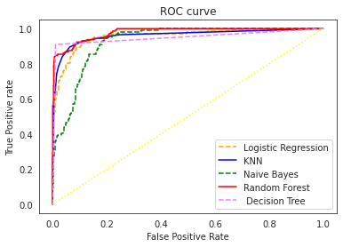

```
ROC_AUC_Score for Logistic Regression is: 0.9567815880039332
ROC_AUC_Score for KNN is: 0.9615469313339888
ROC_AUC_Score for Naive Bayes is: 0.9284302277941658
ROC_AUC_Score for Random Forest is: 0.9793049410029498
ROC_AUC_Score for Decision Tree is: 0.9496988692232056
The Best AUC_SCORE is :0.9793049410029498
```

```python
#Plot Area Under Curve

plt.plot(fpr1,tpr1,linestyle='--',color='orange', label='Logistic Regression')
plt.plot(fpr2,tpr2,linestyle='solid',color='blue', label='KNN')
plt.plot(fpr3,tpr3,linestyle='--',color='Green', label='Naive Bayes')
plt.plot(fpr4,tpr4,linestyle='solid',color='Red', label='Random Forest')
plt.plot(fpr5,tpr5,linestyle='--',color='violet',label=' Decision Tree')

print('The ROC Curve and the Final Report card for the Main Data is here:')

plt.plot(p_fpr, p_tpr, linestyle=':', color='Yellow')
plt.title('ROC curve')
plt.xlabel('False Positive Rate')
plt.ylabel('True Positive rate')

plt.legend(loc='best')
plt.show();

print("ROC_AUC_Score for Logistic Regression is: {}".format(AUC_LOG_RAW))
print("ROC_AUC_Score for KNN is: {}".format(AUC_KNN_RAW))
print("ROC_AUC_Score for Naive Bayes is: {}".format(AUC_NB_RAW))
print("ROC_AUC_Score for Random Forest is: {}".format(AUC_RF_RAW))
print("ROC_AUC_Score for Decision Tree is: {}".format(AUC_DT_RAW))

print("*******************************************************************")
print("The Best AUC_SCORE is :{}".format(AUC_SCORES.max()))
```

*Observation*:

ROC curve is plotted with TPR (Y-axis) against the FPR (X-axis).

ROC is a probability curve and AUC represents degree or measure of separability. Higher the AUC, better is our model at distinguishing between a customer buying the personal Loan and not buying Personal Loan.

Now, The AUC score for *Random Forest Classifier Model* has the highest number, so does the ROC curve too.

By checking the Accuracy, Precision, Recall , ROC & AUC; the *Decision Tree Classifier Model* on sampled data appears to be the best model for this classification problem. However, considered the chances of Overfitting in Decision Tree, **Random Forest Classifier Model** is recommended.

Now, even though we have got a good accuracy score of 91.8%, We can not consider this score as our data is highly imbalanced.

For Imbalanced datasets it is wise to look for precision and recall rather than accuracy. The Precision for RF Model is 100%, which is great. However, the Recall value is only 15%, this is not satisfactory.

This may have happened due to the imbalance in the dataset.

*So, Is that all?* NO!

We will apply everything same on the Upsampled Dataset now.

#### **6US) Model Training & Prediction** *(US denotes 'Upsampled')*

##### M1US) Logistic Regression Model

Let's apply Logistic Regression method and check the Performance Metrics.

```python
logmodelus = LogisticRegression();
logmodelus.fit(X_upsampled_train, Y_upsampled_train);
```

*Prediction and Evaluation:*

```python
logmodelus.score(X_upsampled_train, Y_upsampled_train)
```

```
0.8963337547408344
```

```python
logmodelus.score(X_upsampled_test, Y_upsampled_test)
```

```
0.9096607669616519
```

```python
logmodelus_predicttr = logmodelus.predict(X_upsampled_train)
```

```python
logmodelus_predictts = logmodelus.predict(X_upsampled_test)
```

```
The Report for Logistic Regression Model on the Upsampled Data is:
```

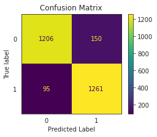

```
              precision    recall  f1-score   support

           0       0.93      0.89      0.91      1356
           1       0.89      0.93      0.91      1356

    accuracy                           0.91      2712
   macro avg       0.91      0.91      0.91      2712
weighted avg       0.91      0.91      0.91      2712

Accuracy Score on Trianing data for Logistic Regression is: 89.63337547408344
Accuracy Score on Test data for Logistic Regression is: 90.96607669616519
F1 Score  for Logistic Regression is: 91.14564510299965
```

```python
print('The Report for Logistic Regression Model on the Upsampled Data is: \n')
matrix = plot_confusion_matrix(logmodelus,X_upsampled_test, Y_upsampled_test, values_format='d')
matrix.ax_.set_title('Confusion Matrix')
plt.xlabel('Predicted Label')
plt.gcf().axes[0].tick_params(color='black')
plt.gcf().axes[0].tick_params(color='black')
plt.gcf().set_size_inches(4,3)
plt.show()

print(classification_report(Y_upsampled_test, logmodelus_predictts))

acc_scoreustr = accuracy_score(Y_upsampled_train, logmodelus_predicttr)
acc_scoreusts = accuracy_score(Y_upsampled_test, logmodelus_predictts)
f1_scoreus = f1_score(Y_upsampled_test, logmodelus_predictts)

print("Accuracy Score on Trianing data for Logistic Regression is: {}".format(acc_scoreustr * 100))
print("Accuracy Score on Test data for Logistic Regression is: {}".format(acc_scoreusts * 100))
print("F1 Score  for Logistic Regression is: {}".format(f1_scoreus * 100))
```

*Observations from LR Model*:

1. **Accuracy**: A good accuracy score of 90.96% on the Test data.
2. **Recall**: A recall value of 93%, which means among the total number of customers who bought the loan, our model has predicted 93% who actually bought the loan. This is great.
3. **Precision**: A Precision value of 89%, which means out of customers who we predicted to buy the loan, 89% of them actually bought the loan. This is a decent score.

##### M2US) K-Nearest Neighbours (KNN) Model

Let's now apply KNN Algorithm and check if the accuracy improves.

```python
knn_modelus = KNeighborsClassifier(n_neighbors=21)
```

```python
knn_modelus.fit(X_upsampled_train,Y_upsampled_train)
```

```
KNeighborsClassifier(algorithm='auto', leaf_size=30, metric='minkowski',
                     metric_params=None, n_jobs=None, n_neighbors=21, p=2,
                     weights='uniform')
```

*Prediction and Evaluation:*

```python
knn_modelus.score(X_upsampled_train, Y_upsampled_train)
```

```
0.9439001264222503
```

```python
knn_modelus.score(X_upsampled_test, Y_upsampled_test)
```

```
0.9417404129793511
```

```python
knn_predictustr = knn_modelus.predict(X_upsampled_train)
```

```python
knn_predictusts = knn_modelus.predict(X_upsampled_test)
```

```
The Report for KNN Classifier Model on the Upsampled Data is:
```

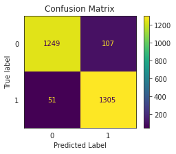

```
              precision    recall  f1-score   support

           0       0.96      0.92      0.94      1356
           1       0.92      0.96      0.94      1356

    accuracy                           0.94      2712
   macro avg       0.94      0.94      0.94      2712
weighted avg       0.94      0.94      0.94      2712

Accuracy Score on Training data for KNN Classifier is: 94.39001264222503
Accuracy Score on Tests data for KNN Classifier is: 94.1740412979351
F1 Score for KNN Classifier is: 94.29190751445087
```

```python
print('The Report for KNN Classifier Model on the Upsampled Data is: \n')
matrix = plot_confusion_matrix(knn_modelus, X_upsampled_test, Y_upsampled_test, values_format='d')
matrix.ax_.set_title('Confusion Matrix')
plt.xlabel('Predicted Label')
plt.gcf().axes[0].tick_params(color='black')
plt.gcf().axes[0].tick_params(color='black')
plt.gcf().set_size_inches(4,3)
plt.show()


print(classification_report(Y_upsampled_test, knn_predictusts))


print("Accuracy Score on Training data for KNN Classifier is: {}".format(accuracy_score(Y_upsampled_train, knn_predictustr) * 100))
print("Accuracy Score on Tests data for KNN Classifier is: {}".format(accuracy_score(Y_upsampled_test, knn_predictusts) * 100))
print("F1 Score for KNN Classifier is: {}".format(f1_score(Y_upsampled_test, knn_predictusts) * 100))
```

*Observations from KNN Model*:

Overall, KNN seems to be the best model so far.

##### M3US) Naive Bayes Model

Let's now check the Decision tree Naive Bayes model.

```python
nb_modelus = GaussianNB()
```

```python
nb_modelus.fit(X_upsampled_train, Y_upsampled_train);
```

*Prediction and Evaluation:*

```python
nb_modelus.score(X_upsampled_train, Y_upsampled_train)
```

```
0.8298040455120101
```

```python
nb_modelus.score(X_upsampled_test, Y_upsampled_test)
```

```
0.834070796460177
```

```python
nb_predictustr = nb_modelus.predict(X_upsampled_train)
```

```python
nb_predictusts = nb_modelus.predict(X_upsampled_test)
```

```
The Report for Naive Bayes Model on the Upsampled Data is:
```

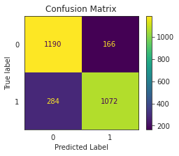

```
              precision    recall  f1-score   support

           0       0.81      0.88      0.84      1356
           1       0.87      0.79      0.83      1356

    accuracy                           0.83      2712
   macro avg       0.84      0.83      0.83      2712
weighted avg       0.84      0.83      0.83      2712

Accuracy Score on Training data for Naive Bayes Model is: 82.98040455120102
Accuracy Score on Test data for Naive Bayes Model is: 83.4070796460177
F1 Score for Naive Bayes Model is: 82.65227447956823
```

```python
print('The Report for Naive Bayes Model on the Upsampled Data is: \n')
matrix = plot_confusion_matrix(nb_modelus, X_upsampled_test, Y_upsampled_test, values_format='d')
matrix.ax_.set_title('Confusion Matrix')
plt.xlabel('Predicted Label')
plt.gcf().axes[0].tick_params(color='black')
plt.gcf().axes[0].tick_params(color='black')
plt.gcf().set_size_inches(4,3)
plt.show()


print(classification_report(Y_upsampled_test, nb_predictus))

acc_score_nbustr = accuracy_score(Y_upsampled_train, nb_predictustr)
acc_score_nbusts = accuracy_score(Y_upsampled_test, nb_predictusts)
f1_score_nbus = f1_score(Y_upsampled_test, nb_predictusts)

print("Accuracy Score on Training data for Naive Bayes Model is: {}".format(acc_score_nbustr * 100))
print("Accuracy Score on Test data for Naive Bayes Model is: {}".format(acc_score_nbusts * 100))
print("F1 Score for Naive Bayes Model is: {}".format(f1_score_nbus * 100))
```

*Observations from NB Model*:

1. **Accuracy**: A descent accuracy score of 83.41% on the Test data.
2. **Recall**: A recall value of 79%, which means among the total number of customers who bought the loan, our model has predicted only 79% who actually bought the loan. This is not great.
3. **Precision**: A Precision value of 87%, which means out of customers who we predicted to buy the loan, 87% of them actually bought the loan. This is a decent score.

##### M4US) Random Forest Classifier

Let's check the Random Forest Classifier performance.

```python
rfmodelus = RandomForestClassifier(max_depth=2)
```

```python
rfmodelus.fit(X_upsampled_train, Y_upsampled_train)
```

```
RandomForestClassifier(bootstrap=True, ccp_alpha=0.0, class_weight=None,
                       criterion='gini', max_depth=2, max_features='auto',
                       max_leaf_nodes=None, max_samples=None,
                       min_impurity_decrease=0.0, min_impurity_split=None,
                       min_samples_leaf=1, min_samples_split=2,
                       min_weight_fraction_leaf=0.0, n_estimators=100,
                       n_jobs=None, oob_score=False, random_state=None,
                       verbose=0, warm_start=False)
```

*Prediction and Evaluation:*

```python
rfmodelus.score(X_upsampled_train, Y_upsampled_train)
```

```
0.9167193426042983
```

```python
rfmodelus.score(X_upsampled_test, Y_upsampled_test)
```

```
0.9192477876106194
```

```python
rf_predictustr = rfmodel.predict(X_upsampled_train)
```

```python
rf_predictusts = rfmodel.predict(X_upsampled_test)
```

```
The Report for Random Forest Model on the Upsampled Data is:
```

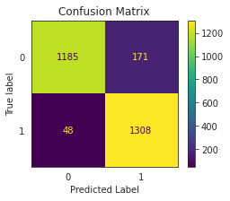

```
              precision    recall  f1-score   support

           0       0.51      1.00      0.68      1356
           1       1.00      0.05      0.10      1356

    accuracy                           0.53      2712
   macro avg       0.76      0.53      0.39      2712
weighted avg       0.76      0.53      0.39      2712

Accuracy Score on Training data for Random Forest Classifier is: 51.88053097345132
Accuracy Score on Test data for Random Forest Classifier is: 52.50737463126843
F1 Score  for Random Forest Classifier is: 9.55056179775281
```

```python
print('The Report for Random Forest Model on the Upsampled Data is: \n')
matrix = plot_confusion_matrix(rfmodelus, X_upsampled_test, Y_upsampled_test, values_format='d')
matrix.ax_.set_title('Confusion Matrix')
plt.xlabel('Predicted Label')
plt.gcf().axes[0].tick_params(color='black')
plt.gcf().axes[0].tick_params(color='black')
plt.gcf().set_size_inches(4,3)
plt.show()

print(classification_report(Y_upsampled_test, rf_predictusts))

acc_score_rfustr = accuracy_score(Y_upsampled_train, rf_predictustr)
acc_score_rfusts = accuracy_score(Y_upsampled_test, rf_predictusts)
f1_score_rfus = f1_score(Y_upsampled_test, rf_predictusts)

print("Accuracy Score on Training data for Random Forest Classifier is: {}".format(acc_score_rfustr * 100))
print("Accuracy Score on Test data for Random Forest Classifier is: {}".format(acc_score_rfusts * 100))
print("F1 Score  for Random Forest Classifier is: {}".format(f1_score_rfus * 100))
```

##### M5US) Decision Tree Classifier

Let's check the Decision Tree Classifier performance.

```python
dtmodelus = DecisionTreeClassifier()
```

```python
dtmodelus.fit(X_upsampled_train, Y_upsampled_train)
```

```
DecisionTreeClassifier(ccp_alpha=0.0, class_weight=None, criterion='gini',
                       max_depth=None, max_features=None, max_leaf_nodes=None,
                       min_impurity_decrease=0.0, min_impurity_split=None,
                       min_samples_leaf=1, min_samples_split=2,
                       min_weight_fraction_leaf=0.0, presort='deprecated',
                       random_state=None, splitter='best')
```

Prediction and Evaluation:

```python
dtmodelus.score(X_upsampled_train, Y_upsampled_train)
```

```
1.0
```

```python
dtmodelus.score(X_upsampled_test, Y_upsampled_test)
```

```
0.9941002949852508
```

```python
dt_predictustr = dtmodel.predict(X_upsampled_train)
```

```python
dt_predictusts = dtmodel.predict(X_upsampled_test)
```

```
The Report for Decision Tree Classifier Model on the Upsampled Data is:
```

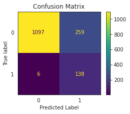

```
              precision    recall  f1-score   support

           0       0.70      0.99      0.82      1356
           1       0.99      0.58      0.73      1356

    accuracy                           0.79      2712
   macro avg       0.84      0.79      0.78      2712
weighted avg       0.84      0.79      0.78      2712

Accuracy Score on Training data for Decision Tree Classifier is: 0.7786030341340076
Accuracy Score on Test data for Decision Tree Classifier is: 0.7850294985250738
F1 Score for Decision Tree Classifier is: 0.711928335690712
```

```python
print('The Report for Decision Tree Classifier Model on the Upsampled Data is: \n')
matrix = plot_confusion_matrix(dtmodelus, X_test, y_test, values_format='d')
matrix.ax_.set_title('Confusion Matrix')
plt.xlabel('Predicted Label')
plt.gcf().axes[0].tick_params(color='black')
plt.gcf().axes[0].tick_params(color='black')
plt.gcf().set_size_inches(4,3)
plt.show()


print(classification_report(Y_upsampled_test, dt_predictusts))


print("Accuracy Score on Training data for Decision Tree Classifier is: {}".format(accuracy_score(Y_upsampled_train, dt_predictustr)))
print("Accuracy Score on Test data for Decision Tree Classifier is: {}".format(accuracy_score(Y_upsampled_test, dt_predictusts)))
print("F1 Score for Decision Tree Classifier is: {}".format(f1_score(Y_upsampled_test, dt_predictus)))
```

#### **7US) Comparing Model performance using ROC & AUC**

Let's use Receiver Operating Characteristic (ROC) curve and find the Area Under Curve (AUC) to evaluate the performance of our models with False postive ratio/True positive ratio.

```python
#Perform Predictions for all the models
PRED_PROB_LOG_RAW=logmodel.predict_proba(X_upsampled_test)
PRED_PROB_KNN_RAW=knn_model.predict_proba(X_upsampled_test)
PRED_PROB_NB_RAW=nb_model.predict_proba(X_upsampled_test)
PRED_PROB_RF_RAW=rfmodel.predict_proba(X_upsampled_test)
PRED_PROB_DT_RAW=dtmodel.predict_proba(X_upsampled_test)
```

```python
#calculate fpr,tpr,threshold
fpr1, tpr1, thresh1 = roc_curve(Y_upsampled_test, PRED_PROB_LOG_RAW[:,1], pos_label=1)
fpr2,tpr2,thresh2 = roc_curve(Y_upsampled_test, PRED_PROB_KNN_RAW[:,1], pos_label=1)
fpr3,tpr3,thresh3 = roc_curve(Y_upsampled_test, PRED_PROB_NB_RAW[:,1], pos_label=1)
fpr4,tpr4,thresh4 = roc_curve(Y_upsampled_test, PRED_PROB_RF_RAW[:,1], pos_label=1)
fpr5,tpr5,thresh5 = roc_curve(Y_upsampled_test, PRED_PROB_DT_RAW[:,1], pos_label=1)

random_probs = [0 for i in range(len(Y_upsampled_test))]
p_fpr, p_tpr, _ = roc_curve(Y_upsampled_test, random_probs, pos_label=1)


AUC_LOG_RAW = roc_auc_score(Y_upsampled_test,PRED_PROB_LOG_RAW[:,1])
AUC_KNN_RAW = roc_auc_score(Y_upsampled_test,PRED_PROB_KNN_RAW[:,1])
AUC_NB_RAW = roc_auc_score(Y_upsampled_test,PRED_PROB_NB_RAW[:,1])
AUC_RF_RAW = roc_auc_score(Y_upsampled_test,PRED_PROB_RF_RAW[:,1])
AUC_DT_RAW = roc_auc_score(Y_upsampled_test,PRED_PROB_DT_RAW[:,1])

AUC_SCORES=pd.array([AUC_LOG_RAW, AUC_KNN_RAW, AUC_NB_RAW, AUC_RF_RAW, AUC_DT_RAW])
```

```
The ROC Curve and the Final Report card for the Upsampled Data is here:
```

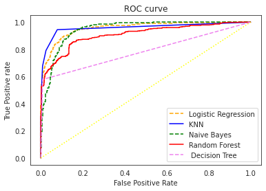

```
ROC_AUC_Score for Logistic Regression is: 0.957692131986321
ROC_AUC_Score for KNN is: 0.9590275602370324
ROC_AUC_Score for Naive Bayes is: 0.9471250902794093
ROC_AUC_Score for Random Forest is: 0.9086872721260693
ROC_AUC_Score for Decision Tree is: 0.7850294985250738
The Best AUC_SCORE is :0.9590275602370324
```

```python
#Plot Area Under Curve

plt.plot(fpr1,tpr1,linestyle='--',color='orange', label='Logistic Regression')
plt.plot(fpr2,tpr2,linestyle='solid',color='blue', label='KNN')
plt.plot(fpr3,tpr3,linestyle='--',color='Green', label='Naive Bayes')
plt.plot(fpr4,tpr4,linestyle='solid',color='Red', label='Random Forest')
plt.plot(fpr5,tpr5,linestyle='--',color='violet',label=' Decision Tree')

print('The ROC Curve and the Final Report card for the Upsampled Data is here:')

plt.plot(p_fpr, p_tpr, linestyle=':', color='Yellow')
plt.title('ROC curve')
plt.xlabel('False Positive Rate')
plt.ylabel('True Positive rate')

plt.legend(loc='best')
plt.show();

print("ROC_AUC_Score for Logistic Regression is: {}".format(AUC_LOG_RAW))
print("ROC_AUC_Score for KNN is: {}".format(AUC_KNN_RAW))
print("ROC_AUC_Score for Naive Bayes is: {}".format(AUC_NB_RAW))
print("ROC_AUC_Score for Random Forest is: {}".format(AUC_RF_RAW))
print("ROC_AUC_Score for Decision Tree is: {}".format(AUC_DT_RAW))

print("*******************************************************************")
print("The Best AUC_SCORE is :{}".format(AUC_SCORES.max()))
```

*Observations:*

ROC curve is plotted with TPR (Y-axis) against the FPR (X-axis).

ROC is a probability curve and AUC represents degree or measure of separability. Higher the AUC, better is our model at distinguishing between a customer buying the personal Loan and not buying Personal Loan.

Now, The AUC score for *KNN Classifier Model* has the highest number, so does the ROC curve too.

By checking the Accuracy, Precision, Recall , ROC & AUC; the **KNN Classifier Model** on upsampled data is the best model for this classification problem.

#### **8) Final Conclusion for the Project:**

- The given data was assessed using a thorough Exploratory Data Analysis.
- For each of the features, Skewness and Outlier Analysis was performed. PoerTransformation was used for the necessary features. This helps increase the accuracy of the model.
- Our target column had high imbalance which would result into a biased model. Upsampling technique was used to mitigate this issue.
- Standardization was performed to increase the learning performance of the model.
- A total of 5 models were tested on the main original data as well as the upsampled data.
- The **Random Forest Classifier** is the best Model for the Main original data fro this project. *Decision Tree Classifier* is also working fine, but there are chances of overfitting in that model, hence may not be recommnded.
- However, since the original data had imbalance, we had done upsampling to mitigate the bias. Thus, for this upsampled data **KNN Classifier** is the best recommended Model.

THE END